# Analyzing Individual BGG Users

Phil Henrickson

2021-12-06

Load previously queried training and test data from the local layer.

Set function for displaying probabilities

Fit models and analyze collection for **Quinns**.

## Games in Collection

How many games has the user owned/played in the training set (games prior to 2020)?

```
## # A tibble: 1 × 3
##   username games_owned games_played
##   <chr>          <dbl>        <dbl>
## 1 Quinns           194          375
```

## Coefficients for Quinns

Examine coefficients from the trained model.

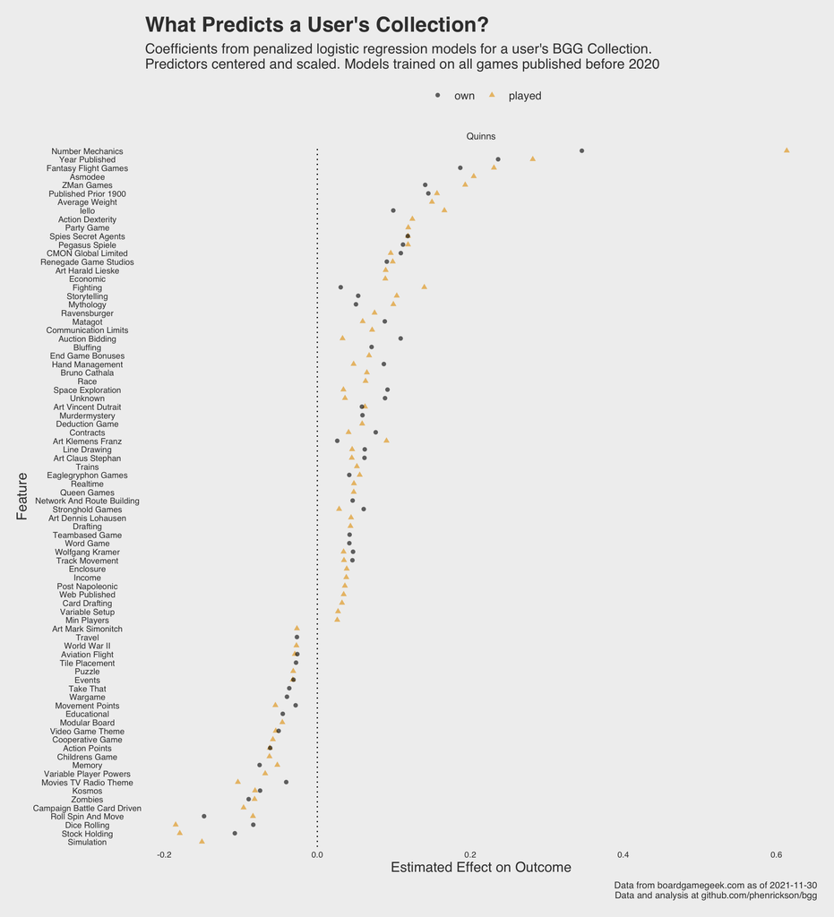

## Visualizing Predictors for Quinns’s Collection

Examine density of most important features for predicting whether user owns a game.

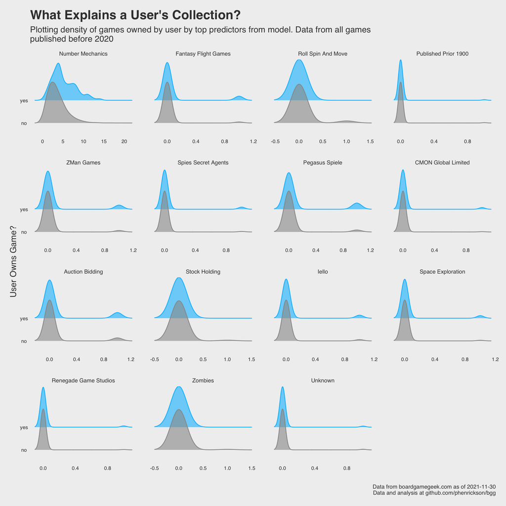

## Assessment

Examine separation plot for training set (cross validated predictions).

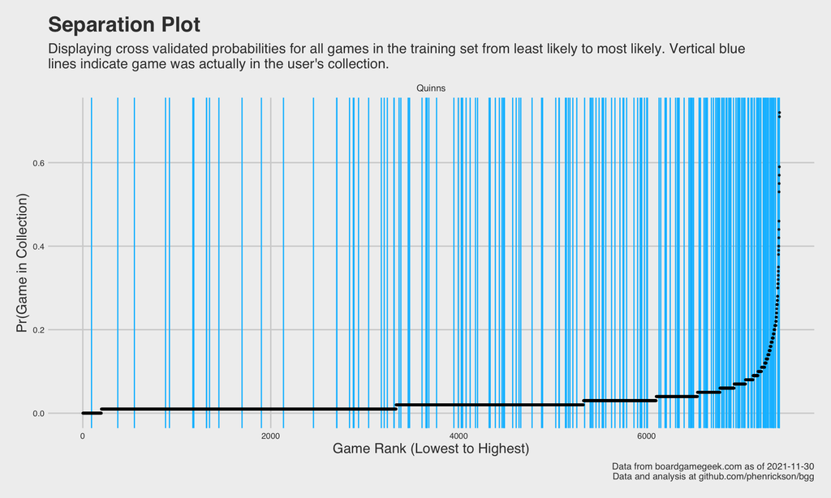

Formally assess how well the model did in resampling.

| outcome_type | .metric | .estimator | .estimate |
| --- | --- | --- | --- |
| own | roc_auc | binary | 0.749 |
| played | roc_auc | binary | 0.831 |

## Predicted Games in Collection from Training

Examine top games from resampling.

Top Overall Games for User from Resampling

| username | yearpublished | game_id | name | pred_played | pred_own | actual_played | actual_own |
| --- | --- | --- | --- | --- | --- | --- | --- |
| Quinns | 2019 | 283863 | The Magnificent | 0.91 | 0.72 | 0 | 0 |
| Quinns | 2017 | 174430 | Gloomhaven | 0.97 | 0.71 | 0 | 0 |
| Quinns | 2008 | 37111 | Battlestar Galactica: The Board Game | 0.86 | 0.59 | 1 | 1 |
| Quinns | 1997 | 42 | Tigris & Euphrates | 0.64 | 0.57 | 1 | 1 |
| Quinns | 2018 | 242639 | Treasure Island | 0.59 | 0.55 | 1 | 1 |
| Quinns | 2018 | 199792 | Everdell | 0.84 | 0.53 | 0 | 0 |
| Quinns | 2018 | 205896 | Rising Sun | 0.98 | 0.46 | 1 | 0 |
| Quinns | 2017 | 233078 | Twilight Imperium: Fourth Edition | 0.84 | 0.44 | 1 | 0 |
| Quinns | 2018 | 313010 | Cosmic Encounter: 42nd Anniversary Edition | 0.74 | 0.42 | 0 | 0 |
| Quinns | 2017 | 220308 | Gaia Project | 0.79 | 0.40 | 1 | 1 |
| Quinns | 2017 | 232979 | Richard the Lionheart | 0.38 | 0.39 | 0 | 0 |
| Quinns | 2013 | 144239 | Impulse | 0.72 | 0.38 | 0 | 0 |
| Quinns | 2008 | 39463 | Cosmic Encounter | 0.69 | 0.35 | 1 | 0 |
| Quinns | 2016 | 155821 | Inis | 0.62 | 0.34 | 1 | 0 |
| Quinns | 2009 | 39683 | At the Gates of Loyang | 0.84 | 0.33 | 0 | 0 |
| Quinns | 2016 | 171131 | Captain Sonar | 0.73 | 0.32 | 1 | 0 |
| Quinns | 2011 | 70919 | Takenoko | 0.70 | 0.31 | 0 | 0 |
| Quinns | 2015 | 181304 | Mysterium | 0.69 | 0.31 | 1 | 0 |
| Quinns | 2016 | 177590 | 13 Days: The Cuban Missile Crisis | 0.52 | 0.30 | 0 | 0 |
| Quinns | 1992 | 118 | Modern Art | 0.49 | 0.30 | 1 | 1 |
| Quinns | 2010 | 73171 | Earth Reborn | 0.79 | 0.28 | 0 | 0 |
| Quinns | 2009 | 45134 | Arcana | 0.32 | 0.28 | 0 | 0 |
| Quinns | 2016 | 187653 | Covert | 0.49 | 0.27 | 0 | 0 |
| Quinns | 2019 | 276025 | Maracaibo | 0.87 | 0.27 | 0 | 0 |
| Quinns | 2018 | 244711 | Newton | 0.95 | 0.26 | 1 | 0 |
| Quinns | 2018 | 259809 | Sonar Family | 0.50 | 0.26 | 0 | 0 |
| Quinns | 2006 | 21241 | Neuroshima Hex! 3.0 | 0.66 | 0.26 | 0 | 0 |
| Quinns | 2019 | 251247 | Barrage | 0.72 | 0.26 | 0 | 0 |
| Quinns | 2019 | 283948 | Marco Polo II: In the Service of the Khan | 0.37 | 0.26 | 0 | 0 |
| Quinns | 2016 | 205398 | Citadels | 0.48 | 0.26 | 0 | 0 |

[output cut: 70 more lines]

### Most and Least Likely Games

What game does the model think Quinns is **most likely to own** that is **not** in their collection?

| username | yearpublished | game_id | name | pred_own |
| --- | --- | --- | --- | --- |
| Quinns | 2019 | 283863 | The Magnificent | 0.72 |

What game does the model think Quinns is **least likely to own** that **is** in their collection?

| username | yearpublished | game_id | name | pred_own |
| --- | --- | --- | --- | --- |
| Quinns | 1966 | 5894 | Twister | 0 |

### Top Games by Year

Top 25 games most likely to be owned by the user in each year, highlighting in blue the games that the user has owned/played.

| rank | 2012 | 2013 | 2014 | 2015 | 2016 | 2017 | 2018 | 2019 |
| --- | --- | --- | --- | --- | --- | --- | --- | --- |
| 1 | Descent: Journeys in the Dark (Second Edition) | Impulse | La Granja | Mysterium | Inis | Gloomhaven | Treasure Island | The Magnificent |
| 2 | Rex: Final Days of an Empire | Tash-Kalar: Arena of Legends | Istanbul | Raiders of the North Sea | Captain Sonar | Twilight Imperium: Fourth Edition | Everdell | Maracaibo |
| 3 | Terra Mystica | Room 25 | Camel Up | Raptor | 13 Days: The Cuban Missile Crisis | Gaia Project | Rising Sun | Barrage |
| 4 | Wiz-War (Eighth Edition) | Legacy: The Testament of Duke de Crecy | Three Kingdoms Redux | Forbidden Stars | Covert | Richard the Lionheart | Cosmic Encounter: 42nd Anniversary Edition | Marco Polo II: In the Service of the Khan |
| 5 | The Resistance: Avalon | Rococo | Deception: Murder in Hong Kong | Blood Rage | Citadels | Santo Domingo | Newton | Circadians: First Light |
| 6 | Robinson Crusoe: Adventures on the Cursed Island | Smash Up: Awesome Level 9000 | Roll for the Galaxy | A Study in Emerald (Second Edition) | Honshū | Unfair | Sonar Family | Paladins of the West Kingdom |
| 7 | Keyflower | Patchistory | Smash Up: Science Fiction Double Feature | Drakon (Fourth Edition) | Aeon's End | Breaking Bad: The Board Game | The World of SMOG: Rise of Moloch | Trails of Tucana |
| 8 | Yedo | Blood Bound | Port Royal | The Voyages of Marco Polo | Terraforming Mars | Jump Drive | The Grizzled: Armistice Edition | Tainted Grail: The Fall of Avalon |
| 9 | Agents of SMERSH | Lewis & Clark: The Expedition | Five Tribes | Risk: Europe | Avenue | Alien Artifacts | Yellow & Yangtze | Amul |
| 10 | The Last Banquet | Smash Up: The Obligatory Cthulhu Set | Ultimate Werewolf | 504 | Coal Baron: The Great Card Game | Smash Up: What Were We Thinking? | Railroad Ink: Deep Blue Edition | Tapestry |
| 11 | Exodus: Proxima Centauri | Ultimate Werewolf: Inquisition | Spyfall | Grand Austria Hotel | Mansions of Madness: Second Edition | Clans of Caledonia | Root | Tiny Towns |
| 12 | Space Cadets | Francis Drake | Arcadia Quest | Haleakala | Kepler-3042 | Wendake | Crown of Emara | The Crew: The Quest for Planet Nine |
| 13 | Android: Infiltration | Pathfinder Adventure Card Game: Rise of the Runelords – Base Set | DungeonQuest Revised Edition | Brick Party | Scythe | Sherlock Holmes Consulting Detective: Carlton House & Queen's Park | Architects of the West Kingdom | Naga Raja |
| 14 | Sewer Pirats | Warhammer: Diskwars | Onirim (Second Edition) | Mission: Red Planet (Second Edition) | Exceed Fighting System | Paper Tales | Underwater Cities | Noctiluca |
| 15 | Winter Tales | A Study in Emerald | Akrotiri | Viticulture Essential Edition | Clank!: A Deck-Building Adventure | Fog of Love | Cosmic Run: Regeneration | Sabotage |
| 16 | Tokaido | Yunnan | Fields of Arle | Tulip Bubble | Sherlock Holmes Consulting Detective: Jack the Ripper & West End Adventures | The Thing: Infection at Outpost 31 | The Pirate Republic | Blitzkrieg!: World War Two in 20 Minutes |
| 17 | Neuroshima: Convoy | City of Remnants | Imperial Settlers | Porta Nigra | Game of Thrones: The Iron Throne | Downforce | Hokkaido | Pax Pamir: Second Edition |
| 18 | Clash of Cultures | Eight-Minute Empire: Legends | Chimera | The Grizzled | Kreus | The Godfather: Corleone's Empire | Gizmos | Ecos: First Continent |
| 19 | P.I. | Empire Engine | [redacted] | Codenames | Black Orchestra | Codenames: Duet | Space Park | Choose Your Own Adventure: War with the Evil Power Master |
| 20 | Kemet | Space Cadets: Dice Duel | Shipwrights of the North Sea | Clockwork Wars | Dokmus | Sagrada | Decrypto | Sierra West |
| 21 | Urbion | Space Sheep! | Sheriff of Nottingham | My Village | Yokohama | Muse | Gingerbread House | Pipeline |
| 22 | Legends of Andor | Two Rooms and a Boom | Splendor | Warhammer Quest: The Adventure Card Game | Timebomb | Campy Creatures | Founders of Gloomhaven | Dungeon Academy |
| 23 | Zombicide | Tomorrow | Tiny Epic Kingdoms | Bullfrogs | Chariot Race | Mythic Battles: Pantheon | DC Spyfall | Cartographers |
| 24 | Rent a Hero | Carcassonne: South Seas | Deus | Karuba | AssassinCon | SpyNet | The Boldest | Aeon's End: Legacy |
| 25 | Polis: Fight for the Hegemony | Bruxelles 1893 | Melee | Watson & Holmes | Time Bomb Evolution | A Handful of Stars | Detective: A Modern Crime Board Game | Nova Luna |

### Interactive Table

Interactive table for predictions from resampling.

|  | username | yearpublished | rank | game_id | name | pred_played | pred_own | actual_played | actual_own |
| --- | --- | --- | --- | --- | --- | --- | --- | --- | --- |
| 1 | Quinns | 1900 | 334 | 15878 | Rummy | 0.01 | 0.08 | 0 | 0 |
| 2 | Quinns | 1900 | 452 | 9364 | Doppelkopf | 0.11 | 0.07 | 0 | 0 |
| 3 | Quinns | 1900 | 566 | 6819 | Skat | 0.02 | 0.06 | 0 | 0 |
| 4 | Quinns | 1900 | 652 | 2932 | Hnefatafl | 0.02 | 0.05 | 0 | 0 |
| 5 | Quinns | 1900 | 701 | 2173 | 4 Player Chess | 0.04 | 0.05 | 0 | 0 |
| 6 | Quinns | 1900 | 777 | 15549 | Roulette | 0.02 | 0.05 | 0 | 0 |
| 7 | Quinns | 1900 | 875 | 11901 | Tic-Tac-Toe | 0 | 0.04 | 0 | 0 |
| 8 | Quinns | 1900 | 889 | 2389 | Othello | 0.04 | 0.04 | 0 | 0 |
| 9 | Quinns | 1900 | 921 | 7316 | Bingo | 0 | 0.04 | 0 | 0 |
| 10 | Quinns | 1900 | 1038 | 2398 | Cribbage | 0.02 | 0.04 | 0 | 0 |

[output cut: 7403 more lines]

## Predicted Games in Collection 2020 and On

Examine the top games for the test set.

Top Predicted Games for User, 2020 and On

| username | yearpublished | game_id | name | rank | own | played |
| --- | --- | --- | --- | --- | --- | --- |
| Quinns | 2020 | 184267 | On Mars | 1 | 0.55 | 0.94 |
| Quinns | 2020 | 301880 | Raiders of Scythia | 2 | 0.37 | 0.38 |
| Quinns | 2020 | 246900 | Eclipse: Second Dawn for the Galaxy | 3 | 0.34 | 0.61 |
| Quinns | 2020 | 300322 | Hallertau | 4 | 0.26 | 0.82 |
| Quinns | 2020 | 256317 | Guild Master | 5 | 0.23 | 0.75 |
| Quinns | 2020 | 298572 | Cosmic Encounter Duel | 6 | 0.22 | 0.51 |
| Quinns | 2020 | 291457 | Gloomhaven: Jaws of the Lion | 7 | 0.17 | 0.83 |
| Quinns | 2020 | 295646 | Spyfest | 8 | 0.17 | 0.43 |
| Quinns | 2020 | 281655 | High Frontier 4 All | 9 | 0.16 | 0.15 |
| Quinns | 2020 | 320819 | Dinner In Paris | 10 | 0.16 | 0.51 |
| Quinns | 2020 | 314040 | Pandemic Legacy: Season 0 | 11 | 0.16 | 0.51 |
| Quinns | 2020 | 296151 | Viscounts of the West Kingdom | 12 | 0.16 | 0.42 |
| Quinns | 2020 | 306481 | Tawantinsuyu: The Inca Empire | 13 | 0.15 | 0.43 |
| Quinns | 2020 | 257193 | Starcadia Quest | 14 | 0.15 | 0.18 |
| Quinns | 2020 | 274841 | Cóatl | 15 | 0.15 | 0.11 |
| Quinns | 2020 | 307844 | Atheneum: Mystic Library | 16 | 0.14 | 0.31 |
| Quinns | 2020 | 297030 | Tekhenu: Obelisk of the Sun | 17 | 0.14 | 0.57 |
| Quinns | 2020 | 306040 | Merv: The Heart of the Silk Road | 18 | 0.13 | 0.28 |
| Quinns | 2020 | 298638 | Sheriff of Nottingham (2nd Edition) | 19 | 0.12 | 0.22 |
| Quinns | 2020 | 253506 | Versailles 1919 | 20 | 0.11 | 0.17 |
| Quinns | 2020 | 293531 | Detective: A Modern Crime Board Game – Season One | 21 | 0.11 | 0.23 |
| Quinns | 2020 | 299074 | Space Battle Lunchtime Card Game | 22 | 0.11 | 0.09 |
| Quinns | 2020 | 300001 | Renature | 23 | 0.11 | 0.19 |
| Quinns | 2020 | 245659 | Vampire: The Masquerade – Vendetta | 24 | 0.11 | 0.15 |
| Quinns | 2020 | 317105 | Tiny Epic Galaxies BLAST OFF! | 25 | 0.11 | 0.16 |
| Quinns | 2021 | 249277 | Brazil: Imperial | 1 | 0.37 | 0.56 |
| Quinns | 2021 | 285967 | Ankh: Gods of Egypt | 2 | 0.30 | 0.86 |
| Quinns | 2021 | 343905 | Boonlake | 3 | 0.28 | 0.90 |
| Quinns | 2021 | 299255 | Vienna Connection | 4 | 0.27 | 0.66 |
| Quinns | 2021 | 310873 | Carnegie | 5 | 0.25 | 0.83 |

[output cut: 52 more lines]

Interactive table for 2020 and On

|  | username | yearpublished | game_id | name | rank | own | played |
| --- | --- | --- | --- | --- | --- | --- | --- |
| 1 | Quinns | 2020 | 184267 | On Mars | 1 | 0.55 | 0.94 |
| 2 | Quinns | 2020 | 301880 | Raiders of Scythia | 2 | 0.37 | 0.38 |
| 3 | Quinns | 2021 | 249277 | Brazil: Imperial | 3 | 0.37 | 0.56 |
| 4 | Quinns | 2020 | 246900 | Eclipse: Second Dawn for the Galaxy | 4 | 0.34 | 0.61 |
| 5 | Quinns | 2021 | 285967 | Ankh: Gods of Egypt | 5 | 0.3 | 0.86 |
| 6 | Quinns | 2021 | 343905 | Boonlake | 6 | 0.28 | 0.9 |
| 7 | Quinns | 2021 | 299255 | Vienna Connection | 7 | 0.27 | 0.66 |
| 8 | Quinns | 2020 | 300322 | Hallertau | 8 | 0.26 | 0.82 |
| 9 | Quinns | 2021 | 310873 | Carnegie | 9 | 0.25 | 0.83 |
| 10 | Quinns | 2020 | 256317 | Guild Master | 10 | 0.23 | 0.75 |

[output cut: 1566 more lines]